# Chapter 6 practice problems

```r
require(tidyverse)
require(rethinking)
require(dagitty)
```

## 6E1

1. Multicollinearity
2. Collider bias
3. Post-treatment bias
   - this may be a big one in my study. More difficult to understand what exactly the treatment brings about. But if the causal links are maintained, is this a problem?
   - Maybe this is the point of path analysis, breaking each causal link apart to decrease this problem
   - Or maybe that’s for collider bias?

## 6E2

An example of collider bias in my own research would be if my sites were spread across a geographic gradient that differed not in temperature but in some other unobserved variable that affected both temperature and growth. Then conditioning on temperature would induce a non-causal correlation between land cover and growth.

## 6E3

- fork x <- z -> y
  - x and y are independent, conditional on z. If we don’t condition on z, non-causal correlation will exist between x and y
- pipe x -> z -> y
  - x and y are independent conditional on z. Including z in a regression model will make x and y appear to be independent, when in fact they are causally connected.
- collider x -> z <- y
  - x and y are independent, but including z in a regression model will induce a correlation between x and y.
- descendant
  - similar to above, conditioning on a descendant variable of a collider will partially condition on the collider. This can happen when a proxy variable is used - could partially open a backdoor path.

## 6E4

A biased sample could be the result of two or more selection criteria being equally valued and uncorrelated in the selection pool. For example, if I selected nests based on parent activity and heat, and included those variables in a regression, then I might see a non-causal negative correlation between parent activity and heat. As is, we expect there to also be a causal negative correlation between parent activity and heat, so this selection process could prevent accurate estimation of the causal effect. It probably wouldn’t interfere with the direction of the effect, but it could reduce uncertainty associated with the coefficient describing the effect of heat on parent activity, exaggerating the causal effect’s significance.

## 6M1

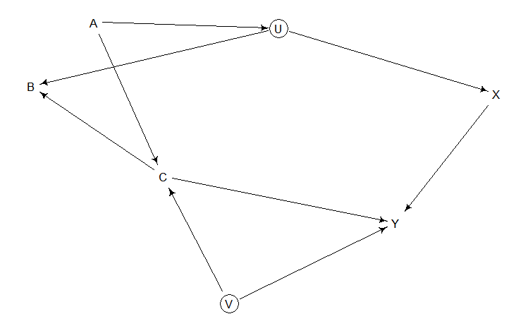

```r
sixm1 <- dagitty( "dag {
U[unobserved]
V[unobserved]
X[exposure]
Y[outcome]
U -> X -> Y <- C
U <- A -> C
U -> B <- C
C <- V -> Y
}")
drawdag( sixm1 )
```

There are five paths: